# Ejercicios_Diagnosis_del_modelo

#### f) Estructura del modelo

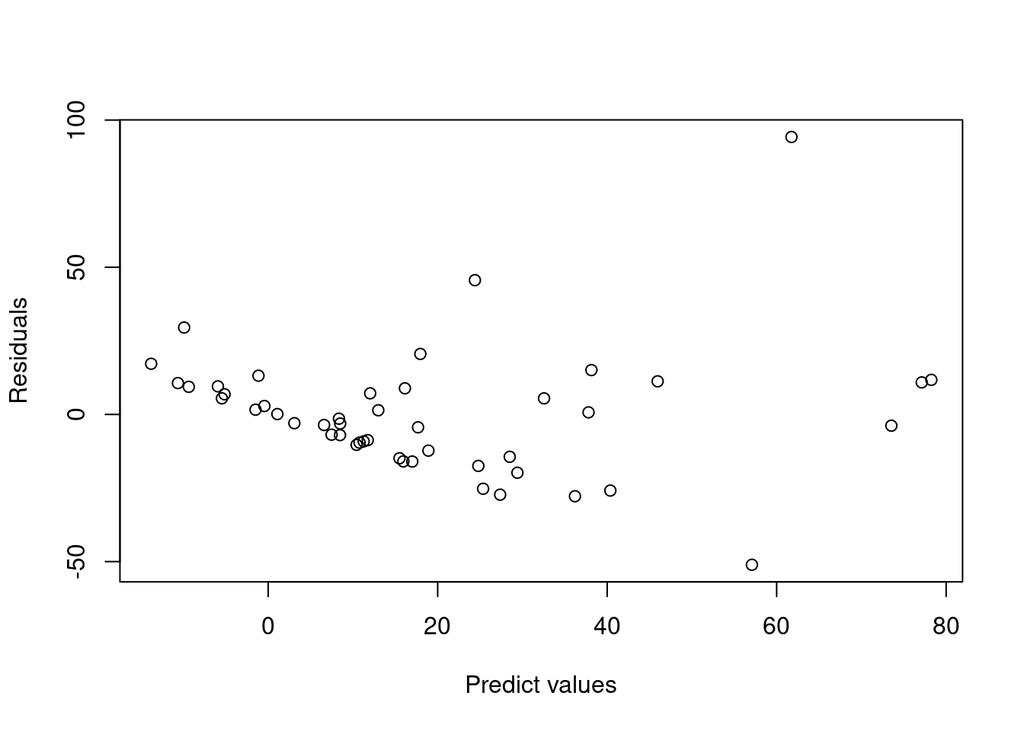

```r
plot(fitted(lmod1),residuals(lmod1),xlab="Predict values",ylab="Residuals")
```

### Problema 6.3. pág. 97

For the prostate data, fit a model with lpsa as the response and the other variables as predictors. Answer the questions posed in the first question.

```r
data(prostate,package="faraway")
head(prostate)
```

```
##       lcavol lweight age      lbph svi      lcp gleason pgg45     lpsa
## 1 -0.5798185  2.7695  50 -1.386294   0 -1.38629       6     0 -0.43078
## 2 -0.9942523  3.3196  58 -1.386294   0 -1.38629       6     0 -0.16252
## 3 -0.5108256  2.6912  74 -1.386294   0 -1.38629       7    20 -0.16252
## 4 -1.2039728  3.2828  58 -1.386294   0 -1.38629       6     0 -0.16252
## 5  0.7514161  3.4324  62 -1.386294   0 -1.38629       6     0  0.37156
## 6 -1.0498221  3.2288  50 -1.386294   0 -1.38629       6     0  0.76547
```

```r
lmod16<-lm(lpsa~.,data=prostate)
summary(lmod16)
```

```
##
## Call:
## lm(formula = lpsa ~ ., data = prostate)
##
## Residuals:
##     Min      1Q  Median      3Q     Max
## -1.7331 -0.3713 -0.0170  0.4141  1.6381
##
## Coefficients:
##              Estimate Std. Error t value Pr(>|t|)
## (Intercept)  0.669337   1.296387   0.516  0.60693
## lcavol       0.587022   0.087920   6.677 2.11e-09 ***
## lweight      0.454467   0.170012   2.673  0.00896 **
## age         -0.019637   0.011173  -1.758  0.08229 .
## lbph         0.107054   0.058449   1.832  0.07040 .
## svi          0.766157   0.244309   3.136  0.00233 **
## lcp         -0.105474   0.091013  -1.159  0.24964
## gleason      0.045142   0.157465   0.287  0.77503
## pgg45        0.004525   0.004421   1.024  0.30886
## ---
## Signif. codes:  0 '***' 0.001 '**' 0.01 '*' 0.05 '.' 0.1 ' ' 1
##
## Residual standard error: 0.7084 on 88 degrees of freedom
## Multiple R-squared:  0.6548, Adjusted R-squared:  0.6234
## F-statistic: 20.86 on 8 and 88 DF,  p-value: < 2.2e-16
```

#### a) Varianza constante

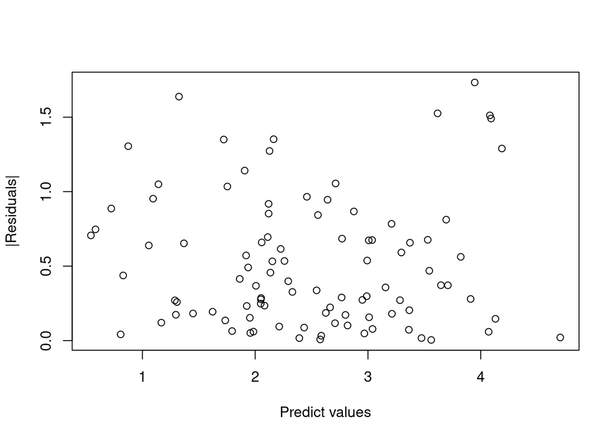

```r
plot(fitted(lmod16),abs(residuals(lmod16)),xlab="Predict values",ylab="|Residuals|")
```

```r
summary(lm(sqrt(abs(residuals(lmod16)))~fitted(lmod16)))
```

```
##
## Call:
## lm(formula = sqrt(abs(residuals(lmod16))) ~ fitted(lmod16))
##
## Residuals:
##      Min       1Q   Median       3Q      Max
## -0.55874 -0.23005 -0.02153  0.19689  0.69990
##
## Coefficients:
##                Estimate Std. Error t value Pr(>|t|)
## (Intercept)     0.70338    0.09061   7.763 9.47e-12 ***
## fitted(lmod16) -0.02199    0.03423  -0.642    0.522
## ---
## Signif. codes:  0 '***' 0.001 '**' 0.01 '*' 0.05 '.' 0.1 ' ' 1
##
## Residual standard error: 0.3133 on 95 degrees of freedom
## Multiple R-squared:  0.004325,   Adjusted R-squared:  -0.006156
## F-statistic: 0.4127 on 1 and 95 DF,  p-value: 0.5222
```

El valor de la pendiente es casi cero, y no se apercia agrupamiento de los datos

#### b) Normalidad

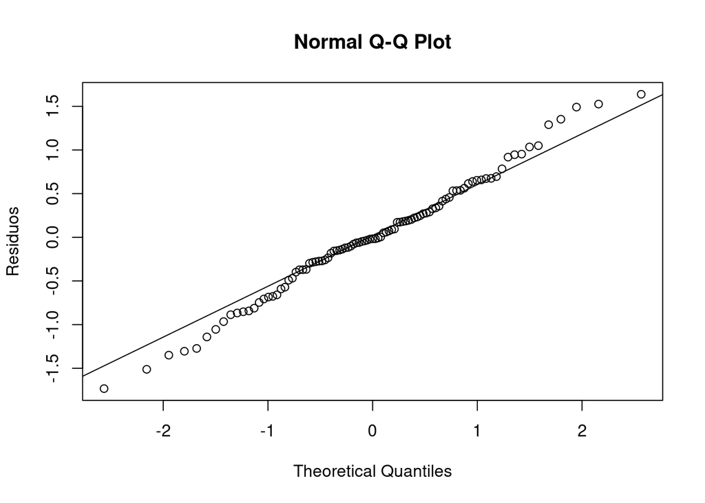

```r
qqnorm(residuals(lmod16),ylab="Residuos")
qqline(residuals(lmod16))
```

Se aprecian indicios de colas largas

```r
shapiro.test(residuals(lmod16))
```

```
##
##  Shapiro-Wilk normality test
##
## data:  residuals(lmod16)
## W = 0.99113, p-value = 0.7721
```

#### c) Leverage

```r
# Residuos con mayor leverage
hatv <- hatvalues(lmod16)
head(sort(hatv,decreasing=T))
```

```
##        32        41        37        92        74        63
## 0.3304757 0.2410079 0.2184392 0.2092421 0.1912109 0.1846807
```

```r
# Residuos con leverage mayor de 2
p <- length(lmod16$coefficients)
n <- length(lmod16$fitted.values)
which(hatv > 2*p/n)
```

```
## 32 37 41 74 92
## 32 37 41 74 92
```

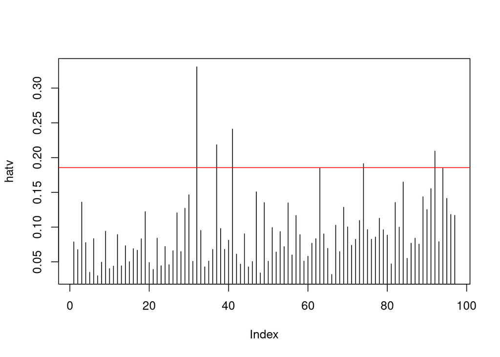

```r
plot(hatv, type="h")
abline(h=2*p/n, col="red")
```

#### d) Outliers

```r
# Residuos studentizados con meadi mayor del doble
stud <- rstudent(lmod16)
head(sort(abs(stud),decreasing=TRUE))
```

```
##       39       69       95       47       97       81
## 2.616980 2.553530 2.385070 2.376671 2.293279 1.987947
```

```r
which(abs(stud)>2)
```

```
## 39 47 69 95 97
## 39 47 69 95 97
```

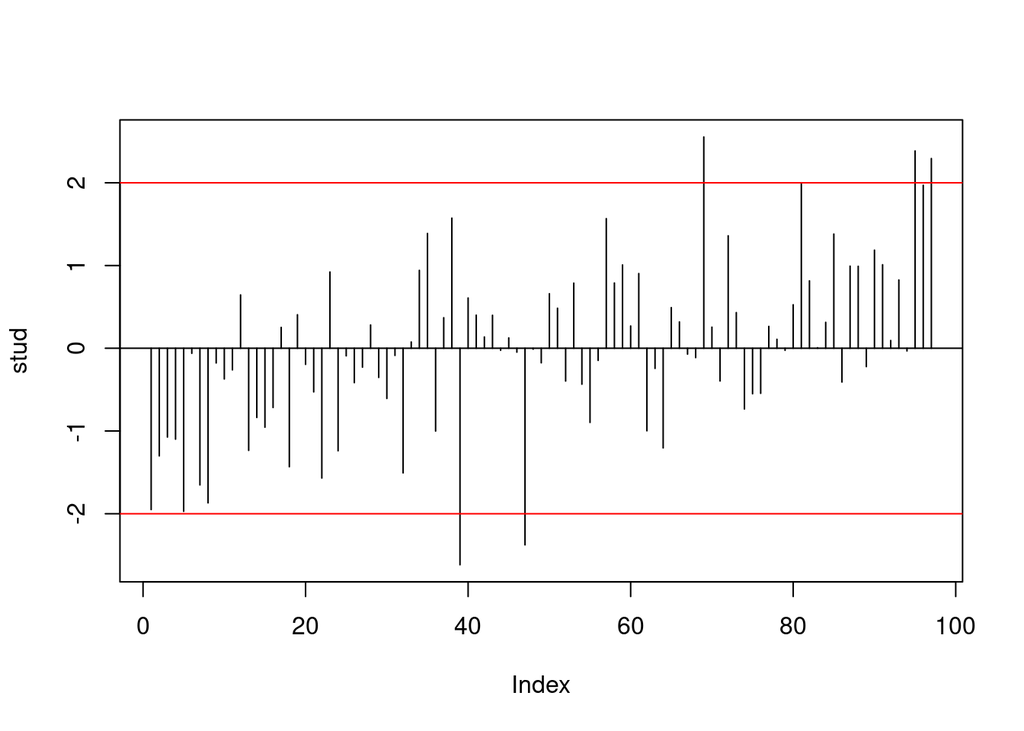

```r
plot(stud, type="h")
abline(h=-2, col="red"); abline(h=0); abline(h=2, col="red")
```

```r
which(abs(stud) > abs(qt(0.05/(2*n),df=n-p-1)))
```

```
## named integer(0)
```

Según Bonferroni, ninguno de los puntos es un outlier

#### e) Observaciones influyentes

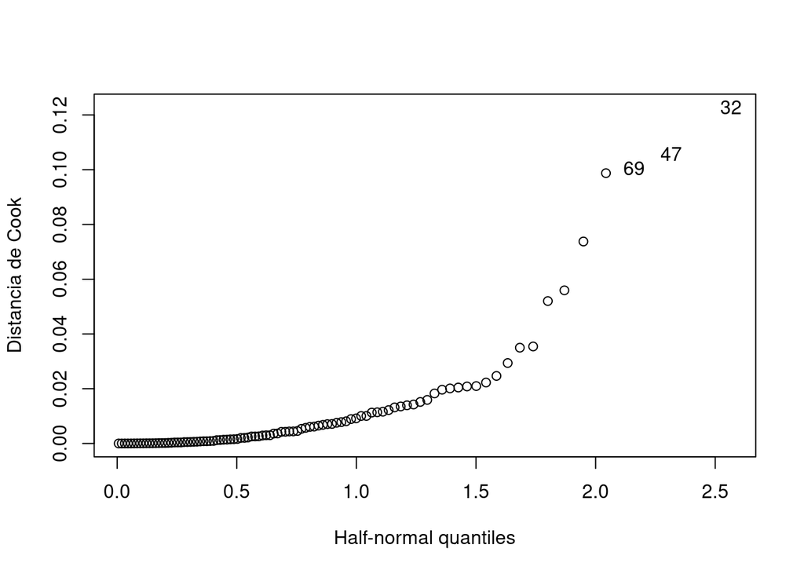

```r
# Distancias de Cook

cook <- cooks.distance(lmod16)
halfnorm(cook,nlab=3,ylab="Distancia de Cook")
```

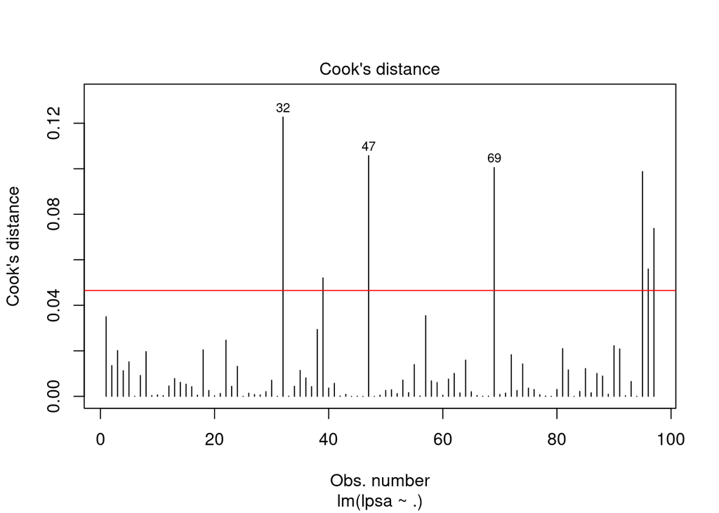

```r
# Puntos influyentes

plot(lmod16, which=4)
abline(h=4/((n-p-2)), col="red")
```

El punto 32 es el más influyente, si ajustamos el modelo sin él:

```r
lmod17 <- lm(lpsa~.,data=prostate[-32,])
summary(lmod17)
```

```
##
## Call:
## lm(formula = lpsa ~ ., data = prostate[-32, ])
##
## Residuals:
##      Min       1Q   Median       3Q      Max
## -1.76425 -0.35383 -0.03029  0.40930  1.55613
##
## Coefficients:
##              Estimate Std. Error t value Pr(>|t|)
## (Intercept)  0.171863   1.328822   0.129  0.89739
## lcavol       0.565333   0.088472   6.390 7.93e-09 ***
## lweight      0.621663   0.202017   3.077  0.00279 **
## age         -0.021271   0.011146  -1.908  0.05963 .
## lbph         0.095590   0.058529   1.633  0.10604
## svi          0.760423   0.242596   3.135  0.00235 **
## lcp         -0.105987   0.090365  -1.173  0.24404
## gleason      0.050688   0.156384   0.324  0.74662
## pgg45        0.004468   0.004390   1.018  0.31155
## ---
## Signif. codes:  0 '***' 0.001 '**' 0.01 '*' 0.05 '.' 0.1 ' ' 1
##
## Residual standard error: 0.7034 on 87 degrees of freedom
## Multiple R-squared:  0.6629, Adjusted R-squared:  0.6319
## F-statistic: 21.39 on 8 and 87 DF,  p-value: < 2.2e-16
```

El cambio es a mejor, pero no demasiado sustancial.

#### f) Estructura del modelo

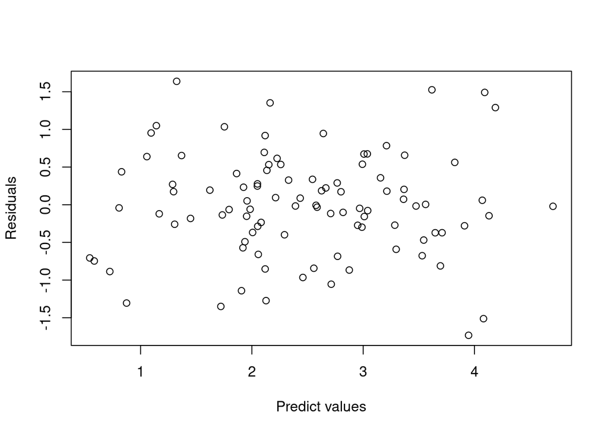

```r
plot(fitted(lmod16),residuals(lmod16),xlab="Predict values",ylab="Residuals")
```

La estructura es máas o menos circular

## Problema 6.4. pag. 97

For the swiss data, fit a model with Fertility as the response and the other variables as predictors. Answer the questions posed in the first question.

```r
data("swiss")
head(swiss)
```

```
##              Fertility Agriculture Examination Education Catholic
## Courtelary        80.2        17.0          15        12     9.96
## Delemont          83.1        45.1           6         9    84.84
## Franches-Mnt      92.5        39.7           5         5    93.40
## Moutier           85.8        36.5          12         7    33.77
## Neuveville        76.9        43.5          17        15     5.16
## Porrentruy        76.1        35.3           9         7    90.57
##              Infant.Mortality
## Courtelary               22.2
## Delemont                 22.2
## Franches-Mnt             20.2
## Moutier                  20.3
## Neuveville               20.6
## Porrentruy               26.6
```

```r
# Modelo
lmod18 <- lm(Fertility~.,data=swiss)
summary(lmod18)
```

```
##
## Call:
## lm(formula = Fertility ~ ., data = swiss)
##
## Residuals:
##      Min       1Q   Median       3Q      Max
## -15.2743  -5.2617   0.5032   4.1198  15.3213
##
## Coefficients:
##                  Estimate Std. Error t value Pr(>|t|)
## (Intercept)      66.91518   10.70604   6.250 1.91e-07 ***
## Agriculture      -0.17211    0.07030  -2.448  0.01873 *
## Examination      -0.25801    0.25388  -1.016  0.31546
## Education        -0.87094    0.18303  -4.758 2.43e-05 ***
## Catholic          0.10412    0.03526   2.953  0.00519 **
## Infant.Mortality  1.07705    0.38172   2.822  0.00734 **
## ---
## Signif. codes:  0 '***' 0.001 '**' 0.01 '*' 0.05 '.' 0.1 ' ' 1
##
## Residual standard error: 7.165 on 41 degrees of freedom
## Multiple R-squared:  0.7067, Adjusted R-squared:  0.671
## F-statistic: 19.76 on 5 and 41 DF,  p-value: 5.594e-10
```

#### a) Varianza constante

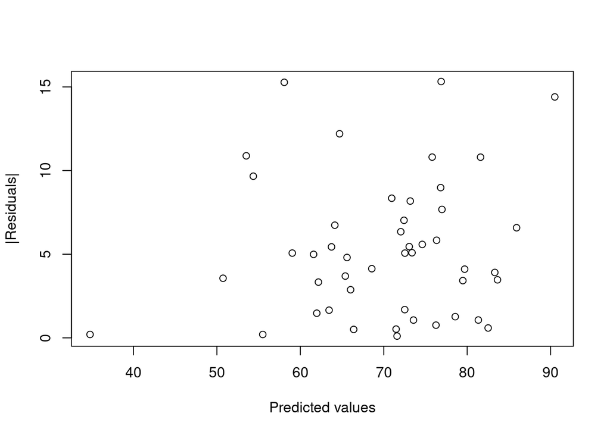

```r
plot(fitted(lmod18),abs(residuals(lmod18)),xlab="Predicted values",ylab="|Residuals|")
```

```r
summary(lm(sqrt(abs(residuals(lmod18)))~fitted(lmod18)))
```

```
##
## Call:
## lm(formula = sqrt(abs(residuals(lmod18))) ~ fitted(lmod18))
##
## Residuals:
##     Min      1Q  Median      3Q     Max
## -1.7992 -0.7539  0.1132  0.5724  1.9678
##
## Coefficients:
##                Estimate Std. Error t value Pr(>|t|)
## (Intercept)     1.15010    0.94993   1.211    0.232
## fitted(lmod18)  0.01361    0.01340   1.016    0.315
##
## Residual standard error: 0.9542 on 45 degrees of freedom
## Multiple R-squared:  0.02242,    Adjusted R-squared:  0.0006947
## F-statistic: 1.032 on 1 and 45 DF,  p-value: 0.3151
```

A priori, no vemos nada anormal

#### b) Normalidad

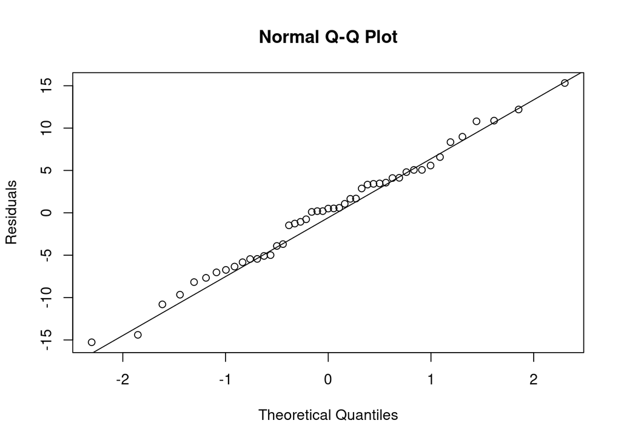

```r
qqnorm(residuals(lmod18),ylab="Residuals")
qqline(residuals(lmod18))
```

```r
shapiro.test(residuals(lmod18))
```

```
##
##  Shapiro-Wilk normality test
##
## data:  residuals(lmod18)
## W = 0.98892, p-value = 0.9318
```

El ajuste es bueno, y la normalidad manifiesta

#### c) Leverage

```r
hatv <- hatvalues(lmod18)
head(sort(hatv,decreasing=T))
```

```
## V. De Geneve    La Vallee La Chauxdfnd  Rive Droite    Neuchatel   Porrentruy
##    0.4558363    0.3512078    0.2262967    0.2106701    0.2053224    0.1983324
```

```r
p <- length(lmod18$coefficients)
n <- length(lmod18$fitted.values)
which(hatv > 2*p/n)
```

```
##    La Vallee V. De Geneve
##           19           45
```

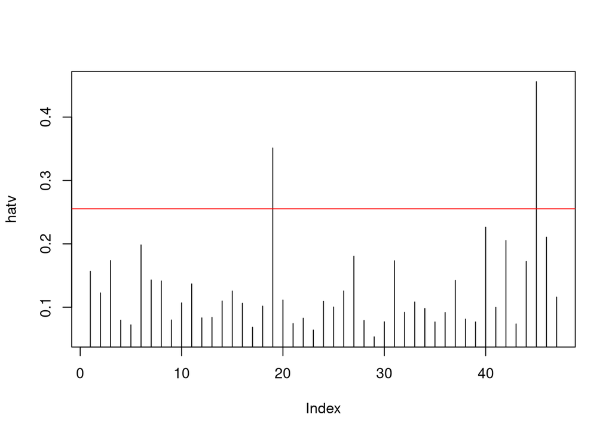

```r
plot(hatv, type="h")
abline(h=2*p/n, col="red")
```

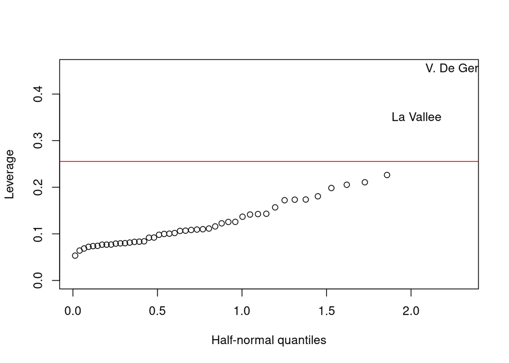

```r
# Hay 2 valores atípicos a priori

halfnorm(hatv,nlab=2,labs=row.names(swiss),ylab="Leverage")
abline(h=2*p/n, col="red")
```

#### d) Valores atípicos (outliers)

```r
# Studentizamos los residuos
stud <- rstudent(lmod18)
head(sort(abs(stud),decreasing=TRUE))
```

```
##      Sierre Rive Gauche  Porrentruy  Neuveville   Neuchatel       Glane
##    2.445227    2.394471    2.367218    1.816142    1.745412    1.661137
```

```r
which(abs(stud)>2)
```

```
##  Porrentruy      Sierre Rive Gauche
##           6          37          47
```

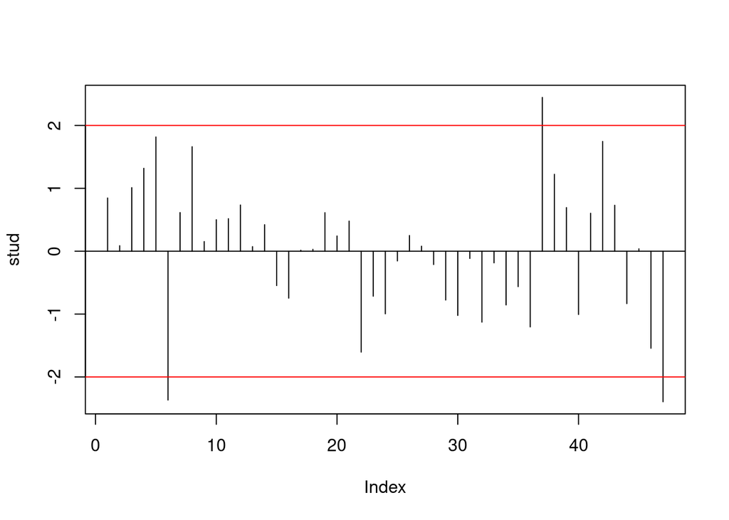

```r
plot(stud, type="h")
abline(h=-2, col="red"); abline(h=0); abline(h=2, col="red")
```

```r
# Según Bonferroni, no podemos considerar ningún punto como un outlier
which(abs(stud) > abs(qt(0.05/(2*n),df=n-p-1)))
```

```
## named integer(0)
```

#### e) Observaciones influyentes

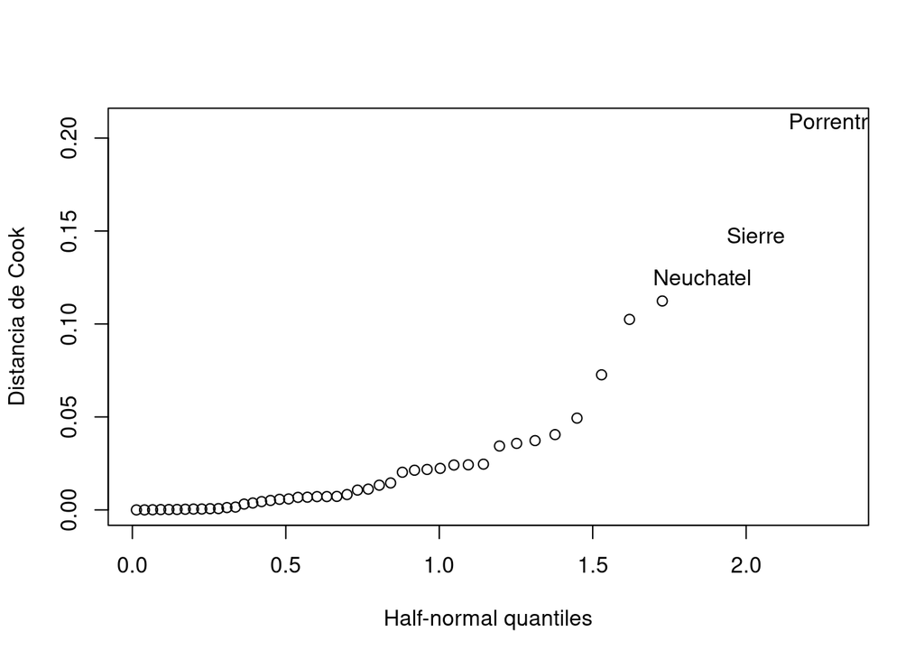

```r
# Distancias de Cook

cook <- cooks.distance(lmod18)
halfnorm(cook,nlab=3,labs=row.names(swiss),ylab="Distancia de Cook")
```

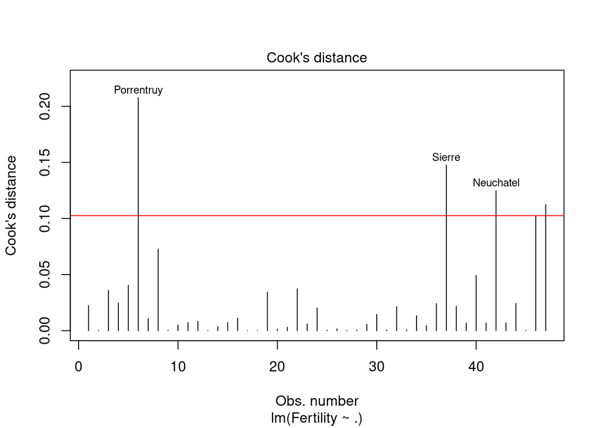

```r
plot(lmod18, which=4)
abline(h=4/((n-p-2)), col="red")
```

Los puntos más influyentes, no coinciden del todo con los más atípicos.

#### f) Estructura del modelo

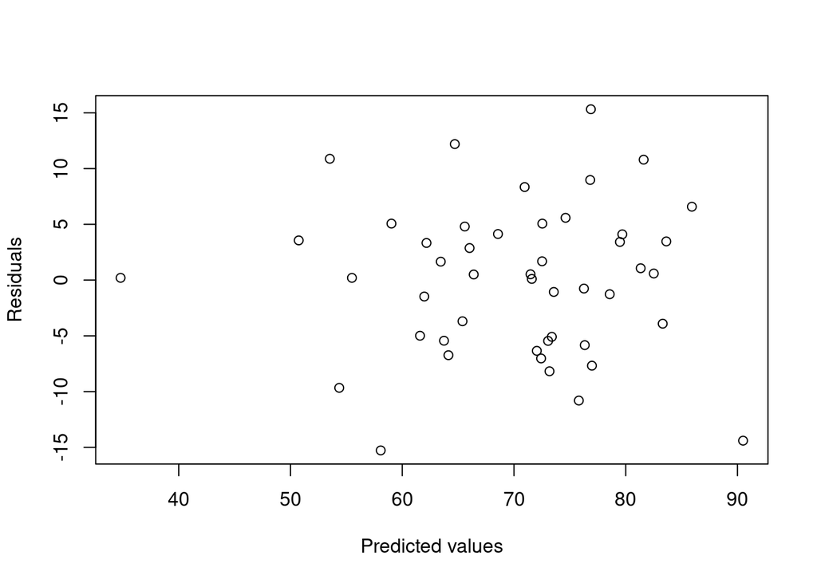

```r
plot(fitted(lmod18),residuals(lmod18),xlab="Predicted values",ylab="Residuals")
```

El modelo parece adecuado

### Problema 6.5. pag. 97

Using the cheddar data, fit a model with taste as the response and the other three variables as predictors. Answer the questions posed in the first question.

```r
data(cheddar,package="faraway")
head(cheddar)
```

```
##   taste Acetic   H2S Lactic
## 1  12.3  4.543 3.135   0.86
## 2  20.9  5.159 5.043   1.53
## 3  39.0  5.366 5.438   1.57
## 4  47.9  5.759 7.496   1.81
## 5   5.6  4.663 3.807   0.99
## 6  25.9  5.697 7.601   1.09
```

```r
# Modelo
lmod19 <- lm(taste~.,data=cheddar)
summary(lmod19)
```

```
##
## Call:
## lm(formula = taste ~ ., data = cheddar)
##
## Residuals:
##     Min      1Q  Median      3Q     Max
## -17.390  -6.612  -1.009   4.908  25.449
##
## Coefficients:
##             Estimate Std. Error t value Pr(>|t|)
## (Intercept) -28.8768    19.7354  -1.463  0.15540
## Acetic        0.3277     4.4598   0.073  0.94198
## H2S           3.9118     1.2484   3.133  0.00425 **
## Lactic       19.6705     8.6291   2.280  0.03108 *
## ---
## Signif. codes:  0 '***' 0.001 '**' 0.01 '*' 0.05 '.' 0.1 ' ' 1
##
## Residual standard error: 10.13 on 26 degrees of freedom
## Multiple R-squared:  0.6518, Adjusted R-squared:  0.6116
## F-statistic: 16.22 on 3 and 26 DF,  p-value: 3.81e-06
```

#### a) Varianza constante

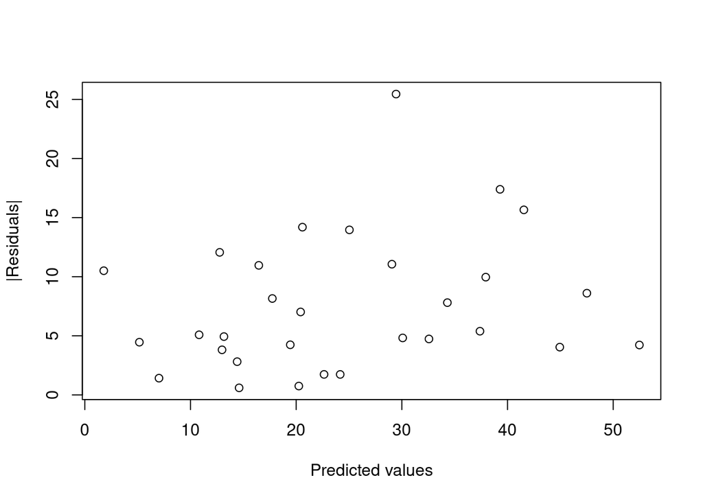

```r
plot(fitted(lmod19),abs(residuals(lmod19)),xlab="Predicted values",ylab="|Residuals|")
```

```r
summary(lm(sqrt(abs(residuals(lmod19)))~fitted(lmod19)))
```

```
##
## Call:
## lm(formula = sqrt(abs(residuals(lmod19))) ~ fitted(lmod19))
##
## Residuals:
##     Min      1Q  Median      3Q     Max
## -1.6144 -0.6536 -0.0760  0.8457  2.3854
##
## Coefficients:
##                Estimate Std. Error t value Pr(>|t|)
## (Intercept)     2.08907    0.39567   5.280 1.29e-05 ***
## fitted(lmod19)  0.01936    0.01427   1.356    0.186
## ---
## Signif. codes:  0 '***' 0.001 '**' 0.01 '*' 0.05 '.' 0.1 ' ' 1
##
## Residual standard error: 1.009 on 28 degrees of freedom
## Multiple R-squared:  0.06166,    Adjusted R-squared:  0.02815
## F-statistic:  1.84 on 1 and 28 DF,  p-value: 0.1858
```

La homocedasticidad parece clara

#### b) Normalidad

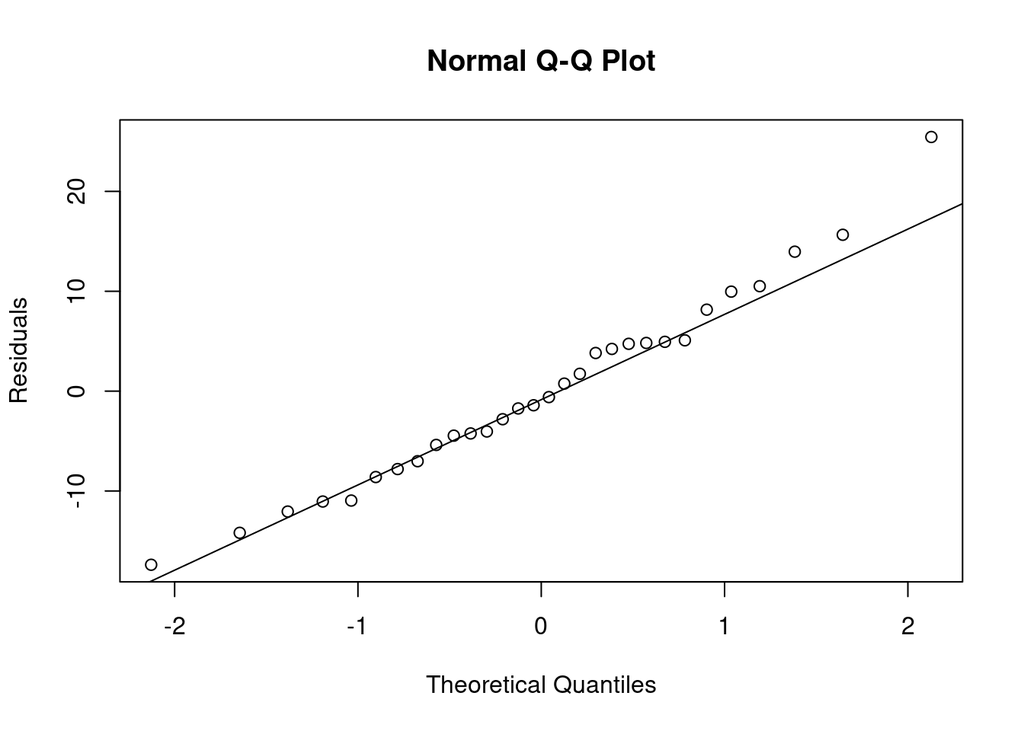

```r
qqnorm(residuals(lmod19),ylab="Residuals")
qqline(residuals(lmod19))
```

```r
shapiro.test(residuals(lmod19))
```

```
##
##  Shapiro-Wilk normality test
##
## data:  residuals(lmod19)
## W = 0.98021, p-value = 0.8312
```

La normalidad es evidente

#### c) Leverage

```r
hatv <- hatvalues(lmod19)
head(sort(hatv,decreasing=T))
```

```
##        26        20        24         6        30         7
## 0.2660631 0.2602910 0.2334368 0.2303671 0.2144534 0.2070990
```

```r
# Comparando con el Leverage medio

p <- length(lmod19$coefficients)
n <- length(lmod19$fitted.values)
which(hatv > 2*p/n)
```

```
## named integer(0)
```

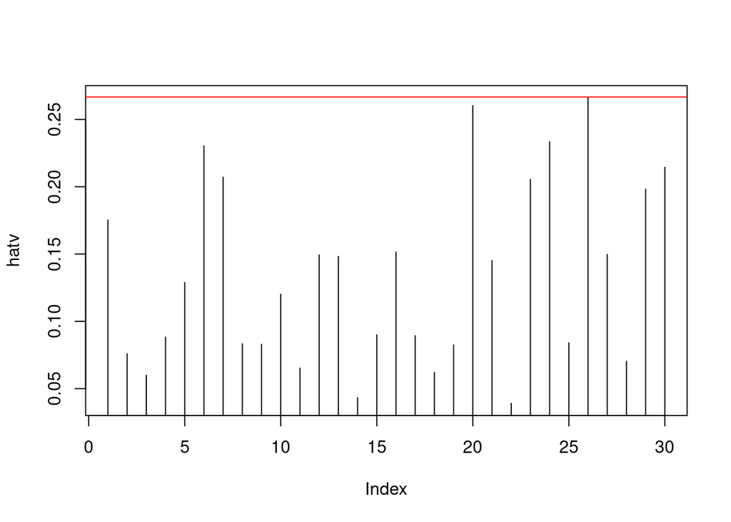

```r
plot(hatv, type="h")
abline(h=2*p/n, col="red")
```

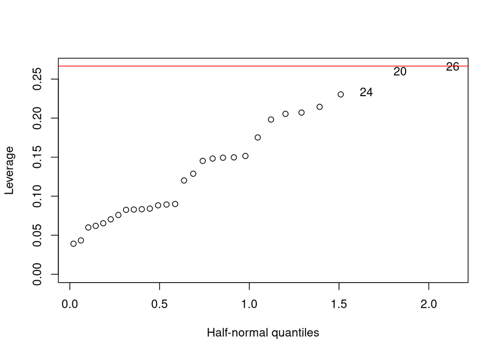

```r
halfnorm(hatv,nlab=3,labs=row.names(cheddar),ylab="Leverage")
abline(h=2*p/n, col="red")
```